# Insights out of 5 millions rides by GoFordBike

## Investigation Overview

In this investigation, I wanted to visualize the relationship between duration of the trip and the covered distance for GoFordBike, and to know when did GoFordBike got many rides and when it didn't.

## Dataset Overview

The dataset contains 26 separate files downloaded from GoFordBike website, each file contains all rides data in a specific month from July 2017 to January 2020, the rides data contains of ride duration, starting and ending locations and timing and the user type. After combining all the 26 files, the combined data counted more than 5 millions rows.

## Distribution of Rides Duration

Rides durations in the dataset take on a very large range of values, from 60 seconds as minimum which is propably due to standard values for shortest rides in the system, and ranges to about 86k seconds at the highest. Plotted on a logarithmic scale, the distribution of durations is normally distributed with small right skew.

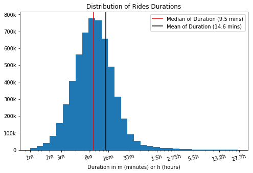

```python
log_binsize = 0.1
bins = 10 ** np.arange(np.log10(60), np.log10(df_improved.duration_sec.max())+log_binsize, log_binsize)

plt.figure(figsize=[8, 5]);
plt.hist(data = df_improved, x = 'duration_sec', bins = bins);
plt.xscale('log');
plt.xlabel('Duration in m (minutes) or h (hours)');
ticks = [60, 120, 180, 480, 960, 1980, 5400, 9900, 19800, 49680, 99720]
ticks_labels = ['1m', '2m', '3m', '8m', '16m', '33m', '1.5h', '2.75h', '5.5h', '13.8h', '27.7h']
ticksy = [0, 100000, 200000, 300000, 400000, 500000, 600000, 700000, 800000]
ticks_labelsy = ['0', '100k', '200k', '300k', '400k', '500k', '600k', '700k', '800k']
plt.xticks(ticks, ticks_labels, rotation=15);
plt.yticks(ticksy, ticks_labelsy);
med = plt.axvline(x=df_improved.duration_sec.median(), c='red');
mean = plt.axvline(x=df_improved.duration_sec.mean(), c='black');
plt.title('Distribution of Rides Durations')
plt.legend((med, mean), ('Median of Duration (9.5 mins)', 'Mean of Duration (14.6 mins)'))
plt.show();
```

## Frequency of stations used as pick up points

There are 453 stations that has bikes by GoFordBike in San Francisco, Here are the top 10 stations used as pick up points for rides.

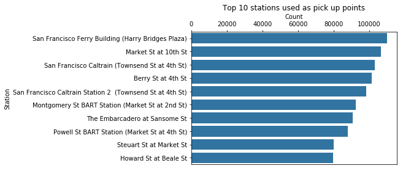

```python
df_cp = df_improved.copy()
df_cp = df_cp[df_cp.start_station_name.isnull()==False]


base_color = sb.color_palette()[0];
ax = sb.countplot(data = df_cp, y = 'start_station_name', color = base_color, order=df_cp.start_station_name.value_counts().index[:10]);
ax.xaxis.tick_top();
ax.set_xlabel('Count');
ax.xaxis.set_label_position('top');
ax.set_ylabel('Station');
ax.set_title('Top 10 stations used as pick up points');
```

## Frequency of stations used as drop off points

There are 453 stations that has bikes by GoFordBike in San Francisco, Here are the top 10 stations used as drop off points for rides.

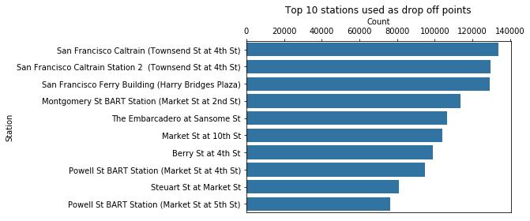

```python
df_cp = df_improved.copy()
df_cp = df_cp[df_cp.end_station_name.isnull()==False]


base_color = sb.color_palette()[0];
ax = sb.countplot(data = df_cp, y = 'end_station_name', color = base_color, order=df_cp.end_station_name.value_counts().index[:10]);
ax.xaxis.tick_top();
ax.set_xlabel('Count');
ax.xaxis.set_label_position('top');
ax.set_ylabel('Station');
ax.set_title('Top 10 stations used as drop off points');
```

## Shares of each type of users for all rides

Out of the 5,705,957 rides, 4,593,295 are subscribers and 1,112,662 are customers

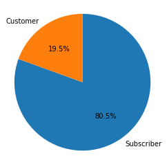

```python
sorted_user_type = df_improved.user_type.value_counts()
plt.pie(sorted_user_type, labels = sorted_user_type.index, startangle = 90,
        counterclock = False, autopct='%1.1f%%');
plt.axis('square');
```

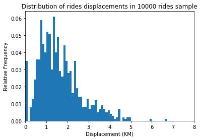

```python
bins = np.arange(0,df_samp.distance_km.max()+0.1, 0.1)

plt.hist(data=df_samp, x='distance_km', bins=bins, weights = np.zeros_like(df_samp.distance_km) + 1. / df_samp.shape[0]);

plt.xlabel('Displacement (KM)');

plt.ylabel('Relative Frequency')
plt.xlim(0,8)
plt.title('Distribution of rides displacements in 10000 rides sample')
plt.show();
```

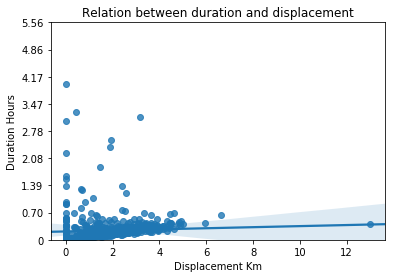

```python
sb.regplot(data = df_samp, x = 'distance_km', y = 'duration_sec');
plt.ylim(0,20000);
plt.xlabel('Displacement Km')
plt.ylabel('Duration Hours')
ticks = [0, 2500, 5000, 7500, 10000, 12500, 15000, 17500, 20000]
ticks_labels = ['0', '0.70', '1.39', '2.08', '2.78', '3.47', '4.17', '4.86', '5.56']
plt.yticks(ticks, ticks_labels);
plt.title('Relation between duration and displacement');
```

## Number of rides per month between July 2017 and January 2020

The average number of rides per month is 187k rides, and the year 2019 is showing great results in against 2018 in terms of number of rides per month.

Also, Decemeber is always associated with lower number of rides per month, which can show that rides decrease in holidays, which also can lead to a conclusion that people use these rides during working times.

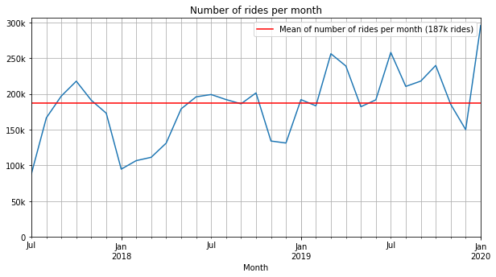

```python
# Plot a time line graph that shows the number of rides per month
plt.figure(figsize=(10,5));
rides_per_month.plot();
plt.xlabel('Month')
plt.title('Number of rides per month')
plt.yticks(np.arange(0, 35e4, 5e4), ['0', '50k', '100k','150k','200k','250k','300k']);
axmean = plt.axhline(y=rides_per_month[1:].mean(), c='red');
plt.legend([axmean], ['Mean of number of rides per month (187k rides)']);
plt.grid(which='both')
```